# Homework02

Zechen Wang (zew20@pitt.edu)

January 27, 2019

## Goal: Explain AmountSpent in terms of the provided customer characteristics.

```r
setwd("D:/workspace/r/INFSCI 2160 Data Mining/Week02")

library(dplyr)
library(ggplot2)
library(glmnet)
library(locfit)
library(tidyr)
library(MASS)
library(rsample)
library(fastDummies)

set.seed(1)
```

## Question #1: Identifying variables

response variable: AmountSpent

predictor variables : Age, Gender, OwnHome, Married, Location, Salary, Children, History, Catalogs

```r
market <- read.csv('HOMEWORK_2_DATASET_DIRECT_MARKETING.csv',header = T,sep = ',')
head(market)
```

```
##      Age Gender OwnHome Married Location Salary Children History Catalogs
## 1    Old Female     Own  Single      Far  47500        0    High        6
## 2 Middle   Male    Rent  Single    Close  63600        0    High        6
## 3  Young Female    Rent  Single    Close  13500        0     Low       18
## 4 Middle   Male     Own Married    Close  85600        1    High       18
## 5 Middle Female     Own  Single    Close  68400        0    High       12
## 6  Young   Male     Own Married    Close  30400        0     Low        6
##   AmountSpent
## 1         755
## 2        1318
## 3         296
## 4        2436
## 5        1304
## 6         495
```

```r
names(market)
```

```
##  [1] "Age"         "Gender"      "OwnHome"     "Married"     "Location"
##  [6] "Salary"      "Children"    "History"     "Catalogs"    "AmountSpent"
```

## Question #2: Exploring the dataset

- There are missing values in the dataset. Describe how you deal with them. (Hint: Check the data description to see what the missingness means.)

```r
summary(market)
```

```
##      Age               Gender            OwnHome            Married
##  Length:1000        Length:1000        Length:1000        Length:1000
##  Class :character   Class :character   Class :character   Class :character
##  Mode  :character   Mode  :character   Mode  :character   Mode  :character
##
##
##
##    Location             Salary          Children       History
##  Length:1000        Min.   : 10100   Min.   :0.000   Length:1000
##  Class :character   1st Qu.: 29975   1st Qu.:0.000   Class :character
##  Mode  :character   Median : 53700   Median :1.000   Mode  :character
##                     Mean   : 56104   Mean   :0.934
##                     3rd Qu.: 77025   3rd Qu.:2.000
##                     Max.   :168800   Max.   :3.000
##     Catalogs      AmountSpent
##  Min.   : 6.00   Min.   :  38.0
##  1st Qu.: 6.00   1st Qu.: 488.2
##  Median :12.00   Median : 962.0
##  Mean   :14.68   Mean   :1216.8
##  3rd Qu.:18.00   3rd Qu.:1688.5
##  Max.   :24.00   Max.   :6217.0
```

```r
head(market[is.na(market$History),], n = 20L)
```

```
##       Age Gender OwnHome Married Location Salary Children History Catalogs
## 10    Old   Male     Own Married      Far  80700        0    <NA>       18
## 11  Young   Male    Rent Married    Close  43700        1    <NA>       12
## 16 Middle Female     Own Married      Far  83100        1    <NA>       12
## 25  Young Female    Rent Married    Close  41700        1    <NA>        6
## 27 Middle   Male     Own  Single    Close  62800        3    <NA>        6
## 30  Young   Male    Rent  Single    Close  21700        1    <NA>       18
## 33 Middle Female    Rent Married    Close  87700        3    <NA>       24
## 39    Old Female     Own Married    Close  41600        0    <NA>       18
## 42 Middle Female     Own Married      Far  96800        3    <NA>       24
## 43 Middle   Male    Rent Married    Close  76200        1    <NA>       24
## 47 Middle   Male     Own Married    Close  77700        0    <NA>        6
## 48  Young   Male     Own Married    Close  58900        0    <NA>       18
## 53 Middle Female     Own Married    Close 105300        1    <NA>       24
## 60  Young Female     Own Married      Far  33700        0    <NA>        6
```

[output cut: 27 more lines]

```r
summary(market[is.na(market$History), "AmountSpent"])
```

```
##    Min. 1st Qu.  Median    Mean 3rd Qu.    Max.
##     106     521    1079    1240    1636    4984
```

```r
summary(market[market$History=="High", "AmountSpent"])
```

```
##    Min. 1st Qu.  Median    Mean 3rd Qu.    Max.    NA's
##     565    1522    1974    2186    2628    6217     303
```

```r
summary(market[market$History=="Medium", "AmountSpent"])
```

```
##    Min. 1st Qu.  Median    Mean 3rd Qu.    Max.    NA's
##   438.0   703.8   894.0   950.4  1149.2  2090.0     303
```

```r
summary(market[market$History=="Low", "AmountSpent"])
```

```
##    Min. 1st Qu.  Median    Mean 3rd Qu.    Max.    NA's
##    38.0   210.0   305.5   357.1   471.5  1120.0     303
```

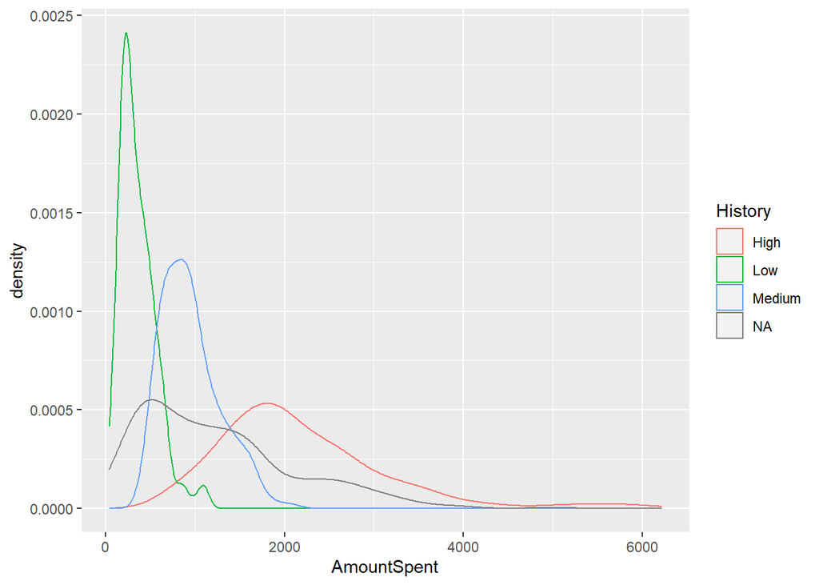

```r
ggplot(data = market) + geom_density(aes(x=AmountSpent, color = History))
```

Fill NAs in History column with “Unknown”.

```r
market$History[is.na(market$History)] <- "Unknown"
summary(market)
```

```
##      Age               Gender            OwnHome            Married
##  Length:1000        Length:1000        Length:1000        Length:1000
##  Class :character   Class :character   Class :character   Class :character
##  Mode  :character   Mode  :character   Mode  :character   Mode  :character
##
##
##
##    Location             Salary          Children       History
##  Length:1000        Min.   : 10100   Min.   :0.000   Length:1000
##  Class :character   1st Qu.: 29975   1st Qu.:0.000   Class :character
##  Mode  :character   Median : 53700   Median :1.000   Mode  :character
##                     Mean   : 56104   Mean   :0.934
##                     3rd Qu.: 77025   3rd Qu.:2.000
##                     Max.   :168800   Max.   :3.000
##     Catalogs      AmountSpent
##  Min.   : 6.00   Min.   :  38.0
##  1st Qu.: 6.00   1st Qu.: 488.2
##  Median :12.00   Median : 962.0
##  Mean   :14.68   Mean   :1216.8
##  3rd Qu.:18.00   3rd Qu.:1688.5
##  Max.   :24.00   Max.   :6217.0
```

```r
str(market)
```

```
## 'data.frame':    1000 obs. of  10 variables:
##  $ Age        : chr  "Old" "Middle" "Young" "Middle" ...
##  $ Gender     : chr  "Female" "Male" "Female" "Male" ...
##  $ OwnHome    : chr  "Own" "Rent" "Rent" "Own" ...
##  $ Married    : chr  "Single" "Single" "Single" "Married" ...
##  $ Location   : chr  "Far" "Close" "Close" "Close" ...
##  $ Salary     : int  47500 63600 13500 85600 68400 30400 48100 68400 51900 80700 ...
##  $ Children   : int  0 0 0 1 0 0 0 0 3 0 ...
##  $ History    : chr  "High" "High" "Low" "High" ...
##  $ Catalogs   : int  6 6 18 18 12 6 12 18 6 18 ...
##  $ AmountSpent: int  755 1318 296 2436 1304 495 782 1155 158 3034 ...
```

- Generate a summary table for the data. For each numerical variable, list the name of it, mean, median, 1st quartile, 3rd quartile, and standard deviation.

```r
summary(market)
```

```
##      Age               Gender            OwnHome            Married
##  Length:1000        Length:1000        Length:1000        Length:1000
##  Class :character   Class :character   Class :character   Class :character
##  Mode  :character   Mode  :character   Mode  :character   Mode  :character
##
##
##
##    Location             Salary          Children       History
##  Length:1000        Min.   : 10100   Min.   :0.000   Length:1000
##  Class :character   1st Qu.: 29975   1st Qu.:0.000   Class :character
##  Mode  :character   Median : 53700   Median :1.000   Mode  :character
##                     Mean   : 56104   Mean   :0.934
##                     3rd Qu.: 77025   3rd Qu.:2.000
##                     Max.   :168800   Max.   :3.000
##     Catalogs      AmountSpent
##  Min.   : 6.00   Min.   :  38.0
##  1st Qu.: 6.00   1st Qu.: 488.2
##  Median :12.00   Median : 962.0
##  Mean   :14.68   Mean   :1216.8
##  3rd Qu.:18.00   3rd Qu.:1688.5
##  Max.   :24.00   Max.   :6217.0
```

```r
summary(market[,unlist(lapply(market, is.numeric))])
```

```
##      Salary          Children        Catalogs      AmountSpent
##  Min.   : 10100   Min.   :0.000   Min.   : 6.00   Min.   :  38.0
##  1st Qu.: 29975   1st Qu.:0.000   1st Qu.: 6.00   1st Qu.: 488.2
##  Median : 53700   Median :1.000   Median :12.00   Median : 962.0
##  Mean   : 56104   Mean   :0.934   Mean   :14.68   Mean   :1216.8
##  3rd Qu.: 77025   3rd Qu.:2.000   3rd Qu.:18.00   3rd Qu.:1688.5
##  Max.   :168800   Max.   :3.000   Max.   :24.00   Max.   :6217.0
```

```r
market_numeric_sd <- matrix(c(sd(market$Salary), sd(market$Children), sd(market$Catalogs), sd(market$AmountSpent)), ncol = 4, byrow = T)
colnames(market_numeric_sd) <- c("Salary", "Children", "Catalogs", "AmountSpent")
rownames(market_numeric_sd) <- c("standard deviation")
market_numeric_sd <- as.table(market_numeric_sd)
market_numeric_sd
```

```
##                          Salary     Children     Catalogs  AmountSpent
## standard deviation 30616.314826     1.051070     6.622895   961.068613
```

- Plot the density distribution of the AmountSpent and Salary variables. What type of shape do they have?

The plot for AmountSpent is skewed and unimodal.

The plot for Salary is skewed and bimodal.

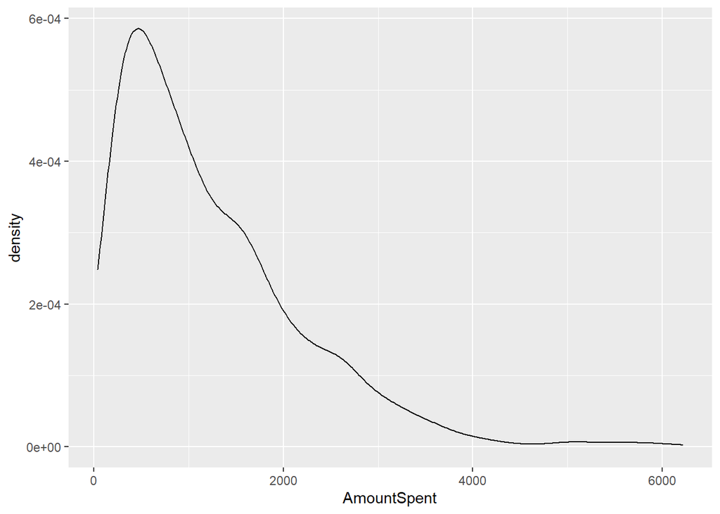

```r
ggplot(market, aes(x = AmountSpent))+geom_density()
```

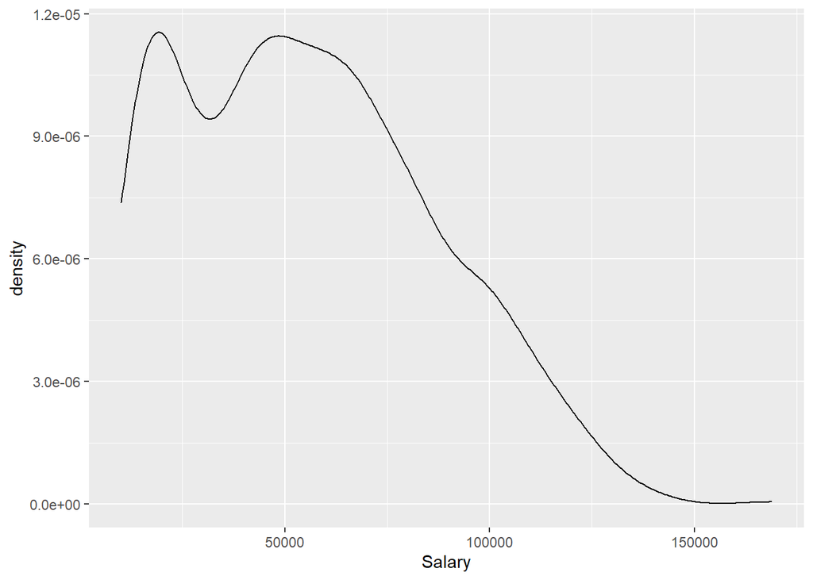

```r
ggplot(market, aes(x = Salary))+geom_density()
```

- Describe the relationship between all the continuous variables and the response variable in terms of correlation and a scatter plot.

```r
cor(market[,c('Salary','AmountSpent')])
```

```
##                Salary AmountSpent
## Salary      1.0000000   0.6995957
## AmountSpent 0.6995957   1.0000000
```

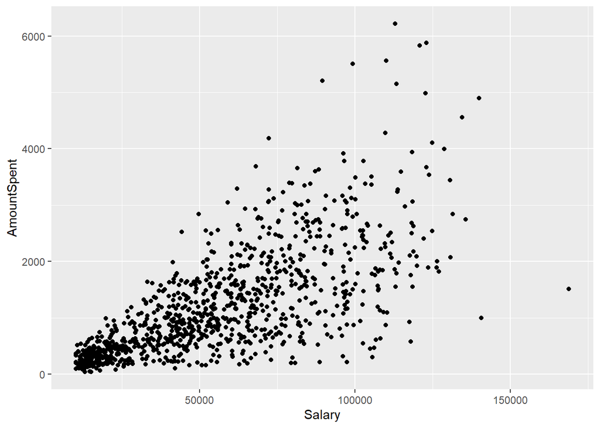

```r
ggplot(market,aes(x = Salary, y = AmountSpent))+geom_point()
```

- For each categorical variable, generate a conditional density plot of the response variable. (Hint: Plot the density of the response variable into multiple distributions separated by the predictor’s categories on the same figure. Use different colors or line shapes to differentiate the categories.)

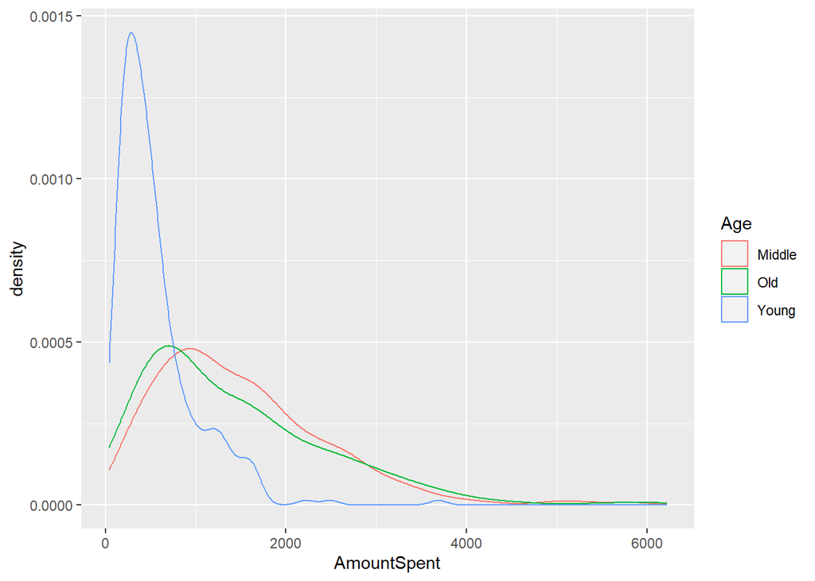

```r
ggplot(data = market) + geom_density(aes(x=AmountSpent, color = Age))
```

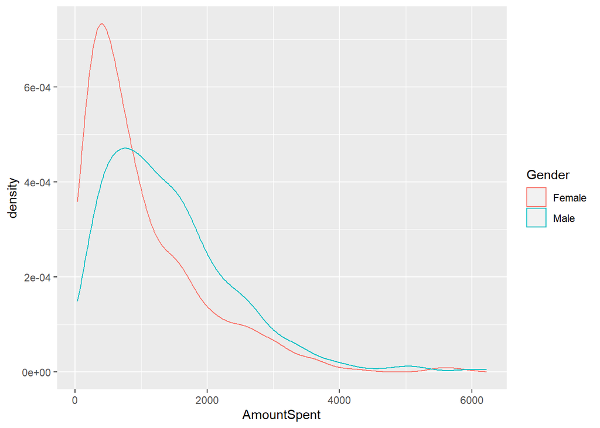

```r
ggplot(data = market) + geom_density(aes(x=AmountSpent, color = Gender))
```

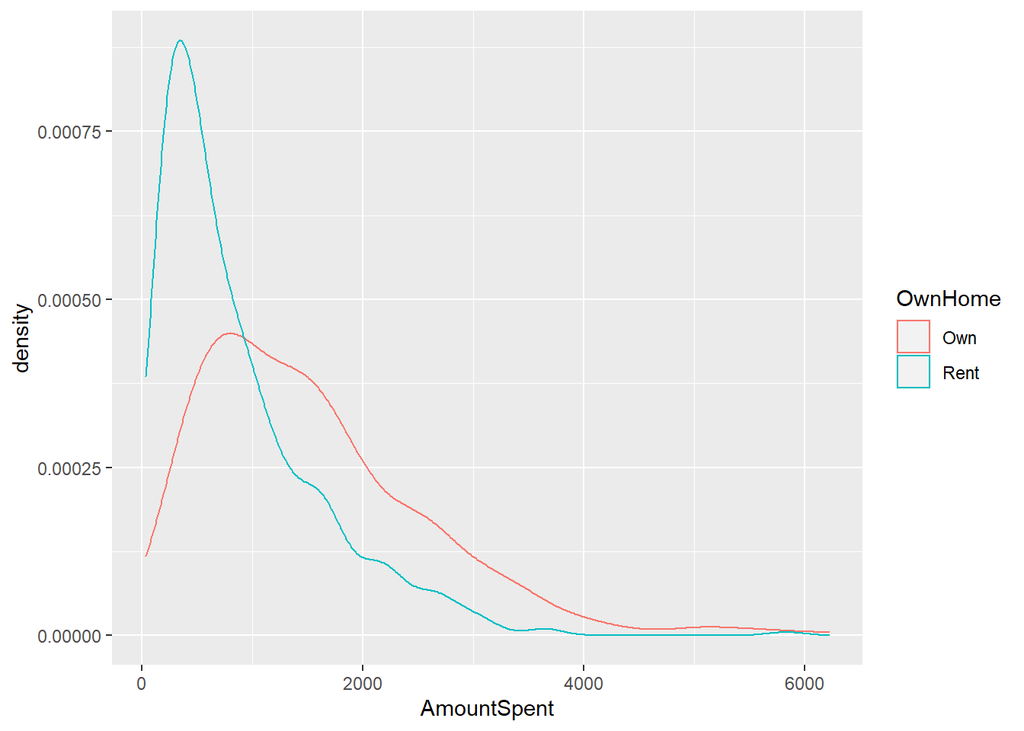

```r
ggplot(data = market) + geom_density(aes(x=AmountSpent, color = OwnHome))
```

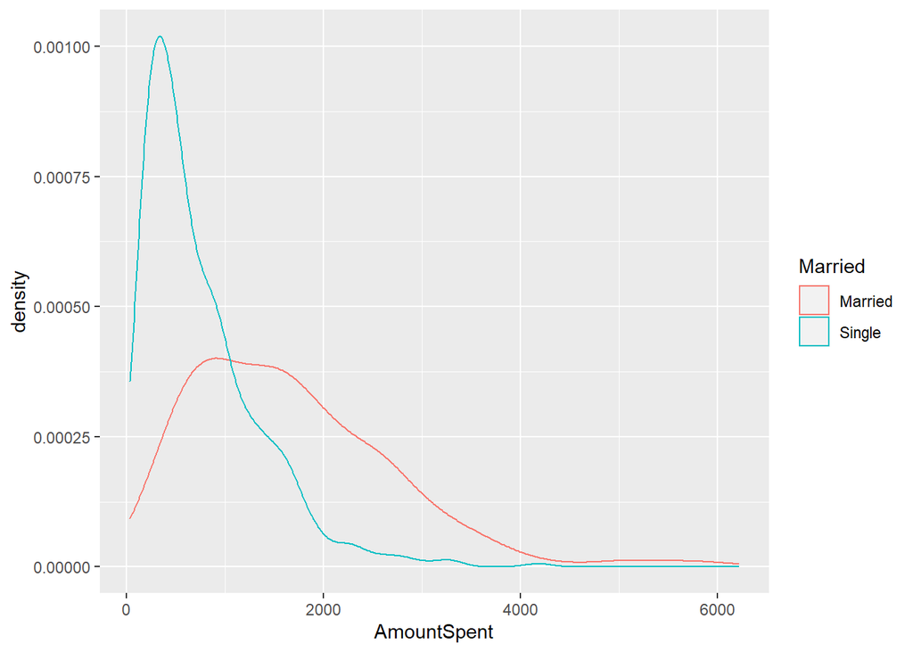

```r
ggplot(data = market) + geom_density(aes(x=AmountSpent, color = Married))
```

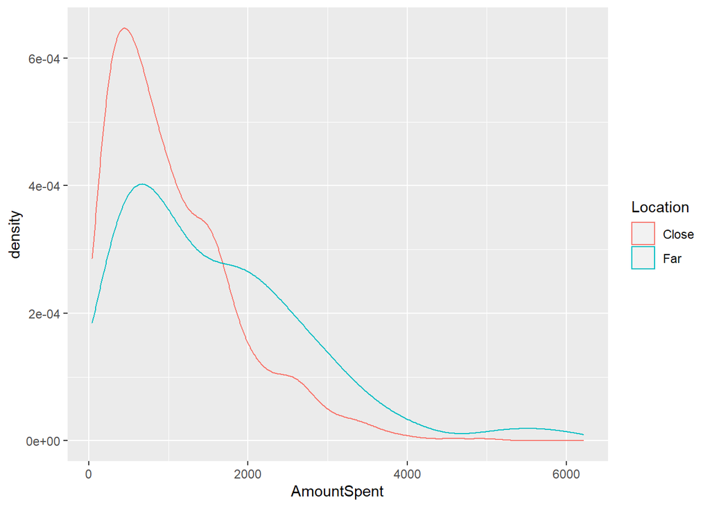

```r
ggplot(data = market) + geom_density(aes(x=AmountSpent, color = Location))
```

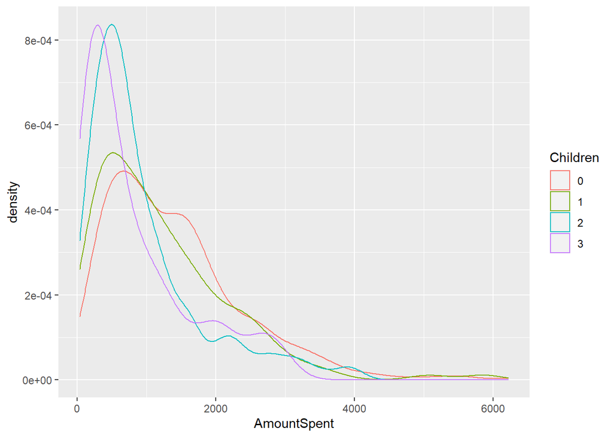

```r
market$Children <- factor(market$Children)
ggplot(data = market) + geom_density(aes(x=AmountSpent, color = Children))
```

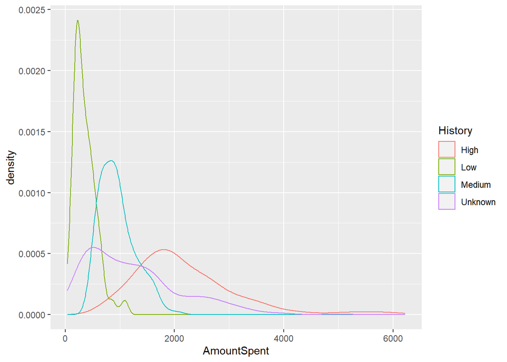

```r
ggplot(data = market) + geom_density(aes(x=AmountSpent, color = History))
```

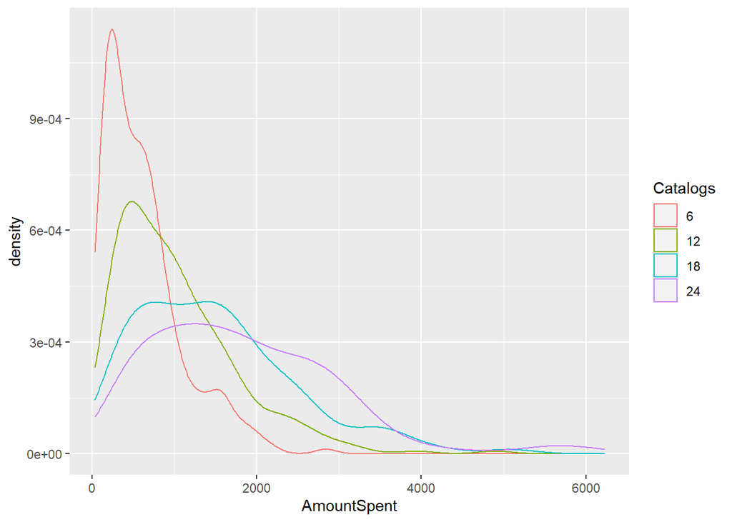

```r
market$Catalogs <- factor(market$Catalogs)
ggplot(data = market) + geom_density(aes(x=AmountSpent, color = Catalogs))
```

## Question 3: Apply regression analysis to the dataset to predict AmountSpent

- Run a multiple linear regression model. How does it perform?

```r
market_origin <- market
market <- dummy_cols(market)
market <- market[c(names(market[10:32]),"Salary")]

normalize <- function(x) {
    x <- as.matrix(x)
    minAttr=apply(x, 2, min)
    maxAttr=apply(x, 2, max)
    x <- sweep(x, 2, minAttr, FUN="-")
    x=sweep(x, 2,  maxAttr-minAttr, "/")
    return (x)
}

market$AmountSpent <- normalize(market$AmountSpent)
market$Salary <- normalize(market$Salary)

m1 <- lm(AmountSpent~., data = market)
summary(m1)
```

```
##
## Call:
## lm(formula = AmountSpent ~ ., data = market)
##
## Residuals:
##      Min       1Q   Median       3Q      Max
## -0.28292 -0.04653 -0.00331  0.03812  0.46324
##
## Coefficients: (7 not defined because of singularities)
##                  Estimate Std. Error t value Pr(>|t|)
## (Intercept)      0.129984   0.012163  10.687  < 2e-16 ***
## Age_Middle      -0.002480   0.008070  -0.307  0.75870
## Age_Old          0.010249   0.009015   1.137  0.25588
## Age_Young              NA         NA      NA       NA
## Gender_Female    0.006766   0.005369   1.260  0.20788
## Gender_Male            NA         NA      NA       NA
## OwnHome_Own      0.003309   0.005945   0.557  0.57799
## OwnHome_Rent           NA         NA      NA       NA
## Married_Married -0.006241   0.007230  -0.863  0.38824
## Married_Single         NA         NA      NA       NA
## Location_Close  -0.070470   0.005818 -12.113  < 2e-16 ***
## Location_Far           NA         NA      NA       NA
## Children_0       0.079543   0.009379   8.481  < 2e-16 ***
## Children_1       0.059150   0.008948   6.611 6.26e-11 ***
## Children_2       0.028451   0.009830   2.894  0.00388 **
## Children_3             NA         NA      NA       NA
## History_High    -0.001736   0.008337  -0.208  0.83507
## History_Low     -0.058205   0.007573  -7.685 3.68e-14 ***
## History_Medium  -0.065724   0.007347  -8.945  < 2e-16 ***
## History_Unknown        NA         NA      NA       NA
## Catalogs_6      -0.119729   0.007506 -15.951  < 2e-16 ***
## Catalogs_12     -0.089167   0.007176 -12.426  < 2e-16 ***
## Catalogs_18     -0.041110   0.007319  -5.617 2.53e-08 ***
## Salary           0.496564   0.026560  18.696  < 2e-16 ***
## ---
## Signif. codes:  0 '***' 0.001 '**' 0.01 '*' 0.05 '.' 0.1 ' ' 1
##
## Residual standard error: 0.07863 on 983 degrees of freedom
## Multiple R-squared:  0.7485, Adjusted R-squared:  0.7444
## F-statistic: 182.9 on 16 and 983 DF,  p-value: < 2.2e-16
```

- Use AIC for feature selection

Evaluate: the multiple R-squared is 0.7478, the adjusted R-squared is 0.745, F-statistic is 266.4 on 11 and 988 DF, p-value is less than 2.2e-16

The model performed best is AmountSpent = 0.134799 + 0.013517 * Age_Old - 0.069985 * Location_Close + 0.077509 * Children_0 + 0.058548 * Children_1 + 0.028053 * Children_2 - 0.057717 * History_Low - 0.065992 * History_Medium - 0.119235 * Catalogs_6 - 0.088409 * Catalogs_12 - 0.040819 * Catalogs_18 + 0.479881 * Salary. Because it has the smallest AIC.

```r
m1_stepwise <- stepAIC(m1, direction = "backward")
```

```
## Start:  AIC=-5069.08
## AmountSpent ~ Age_Middle + Age_Old + Age_Young + Gender_Female +
##     Gender_Male + OwnHome_Own + OwnHome_Rent + Married_Married +
##     Married_Single + Location_Close + Location_Far + Children_0 +
##     Children_1 + Children_2 + Children_3 + History_High + History_Low +
##     History_Medium + History_Unknown + Catalogs_6 + Catalogs_12 +
##     Catalogs_18 + Salary
##
##
## Step:  AIC=-5069.08
## AmountSpent ~ Age_Middle + Age_Old + Age_Young + Gender_Female +
##     Gender_Male + OwnHome_Own + OwnHome_Rent + Married_Married +
##     Married_Single + Location_Close + Location_Far + Children_0 +
##     Children_1 + Children_2 + Children_3 + History_High + History_Low +
##     History_Medium + Catalogs_6 + Catalogs_12 + Catalogs_18 +
##     Salary
##
##
## Step:  AIC=-5069.08
## AmountSpent ~ Age_Middle + Age_Old + Age_Young + Gender_Female +
##     Gender_Male + OwnHome_Own + OwnHome_Rent + Married_Married +
##     Married_Single + Location_Close + Location_Far + Children_0 +
##     Children_1 + Children_2 + History_High + History_Low + History_Medium +
##     Catalogs_6 + Catalogs_12 + Catalogs_18 + Salary
##
##
## Step:  AIC=-5069.08
## AmountSpent ~ Age_Middle + Age_Old + Age_Young + Gender_Female +
##     Gender_Male + OwnHome_Own + OwnHome_Rent + Married_Married +
##     Married_Single + Location_Close + Children_0 + Children_1 +
##     Children_2 + History_High + History_Low + History_Medium +
##     Catalogs_6 + Catalogs_12 + Catalogs_18 + Salary
##
##
## Step:  AIC=-5069.08
## AmountSpent ~ Age_Middle + Age_Old + Age_Young + Gender_Female +
##     Gender_Male + OwnHome_Own + OwnHome_Rent + Married_Married +
##     Location_Close + Children_0 + Children_1 + Children_2 + History_High +
##     History_Low + History_Medium + Catalogs_6 + Catalogs_12 +
##     Catalogs_18 + Salary
```

[output cut: 133 more lines]

```
##     Catalogs_12 + Catalogs_18 + Salary
##
##                  Df Sum of Sq     RSS     AIC
## <none>                         6.0943 -5076.4
## - Age_Old         1    0.0232  6.1176 -5074.6
## - Children_2      1    0.0508  6.1451 -5070.1
## - Catalogs_18     1    0.1926  6.2869 -5047.3
## - Children_1      1    0.2731  6.3674 -5034.6
## - History_Low     1    0.3668  6.4612 -5019.9
## - Children_0      1    0.4667  6.5610 -5004.6
## - History_Medium  1    0.6142  6.7085 -4982.4
## - Location_Close  1    0.9472  7.0415 -4933.9
## - Catalogs_12     1    0.9705  7.0649 -4930.6
## - Catalogs_6      1    1.5992  7.6936 -4845.4
## - Salary          1    6.3085 12.4028 -4367.8
```

```r
summary(m1_stepwise)
```

```
##
## Call:
## lm(formula = AmountSpent ~ Age_Old + Location_Close + Children_0 +
##     Children_1 + Children_2 + History_Low + History_Medium +
##     Catalogs_6 + Catalogs_12 + Catalogs_18 + Salary, data = market)
##
## Residuals:
##      Min       1Q   Median       3Q      Max
## -0.27794 -0.04636 -0.00299  0.03811  0.46333
##
## Coefficients:
##                 Estimate Std. Error t value Pr(>|t|)
## (Intercept)     0.134799   0.011367  11.858  < 2e-16 ***
## Age_Old         0.013517   0.006963   1.941  0.05251 .
## Location_Close -0.069985   0.005648 -12.392  < 2e-16 ***
## Children_0      0.077509   0.008911   8.698  < 2e-16 ***
## Children_1      0.058548   0.008799   6.654 4.73e-11 ***
## Children_2      0.028053   0.009779   2.869  0.00421 **
## History_Low    -0.057717   0.007484  -7.712 3.02e-14 ***
## History_Medium -0.065992   0.006613  -9.979  < 2e-16 ***
## Catalogs_6     -0.119235   0.007405 -16.102  < 2e-16 ***
## Catalogs_12    -0.088409   0.007048 -12.544  < 2e-16 ***
## Catalogs_18    -0.040819   0.007306  -5.587 2.98e-08 ***
## Salary          0.479881   0.015006  31.980  < 2e-16 ***
## ---
## Signif. codes:  0 '***' 0.001 '**' 0.01 '*' 0.05 '.' 0.1 ' ' 1
##
## Residual standard error: 0.07854 on 988 degrees of freedom
## Multiple R-squared:  0.7478, Adjusted R-squared:  0.745
## F-statistic: 266.4 on 11 and 988 DF,  p-value: < 2.2e-16
```

- Use lasso for feature selection.

Statistically significant variables are: Age_Middle, Age_Old, Gender_Female, OwnHome_Own, Married_Married, Married_Single, Location_Close, Children_0, Children_2, Children_3, History_High, History_Low, History_Medium, Catalogs_6, Catalogs_12, Catalogs_18, Salary

Evaluate: The mean squared error for this model is 0.004723122.

The best model is the model which lambda is equal to lambda.min (in this case, it is 0.0001828839, as shown below).

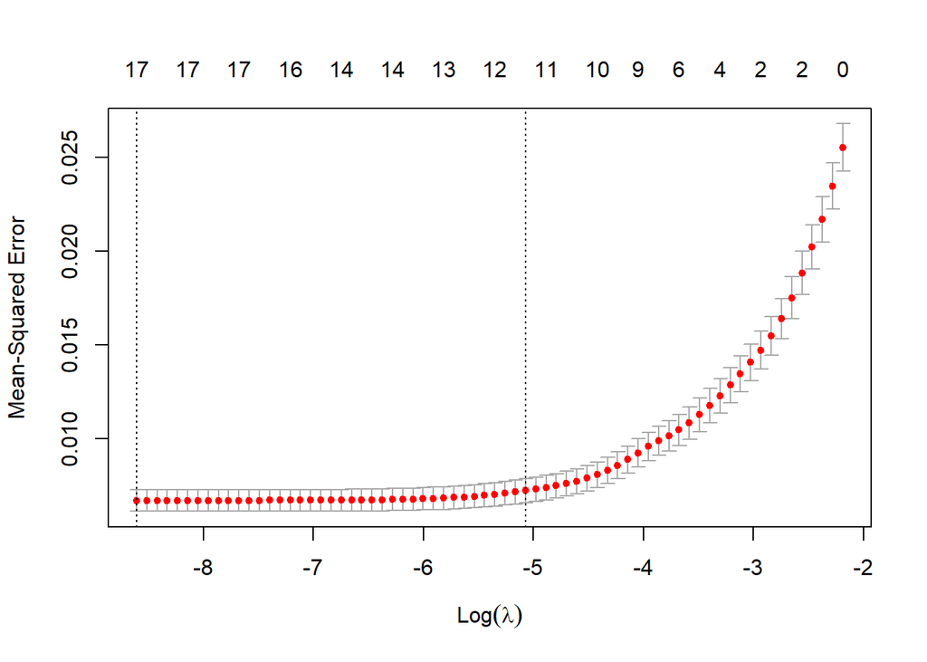

```r
market_train_test_split <- initial_split(market, prop = 0.80)
market_train_tbl <- training(market_train_test_split)
market_test_tbl <- testing(market_train_test_split)
market_vars_train <- market_train_tbl[, c(names(market[-1]))]
market_vars_test <- market_test_tbl[, c(names(market[-1]))]
market_target_train <- market_train_tbl[, c("AmountSpent")]
market_target_test <- market_test_tbl[, c("AmountSpent")]

market_cv_lasso <- cv.glmnet(x = as.matrix(market_vars_train), y = market_target_train, alpha = 1)
plot(market_cv_lasso)
```

```r
market_cv_lasso$lambda.min
```

```
## [1] 0.0001828839
```

```r
market_cv_lasso$lambda.1se
```

```
## [1] 0.006273775
```

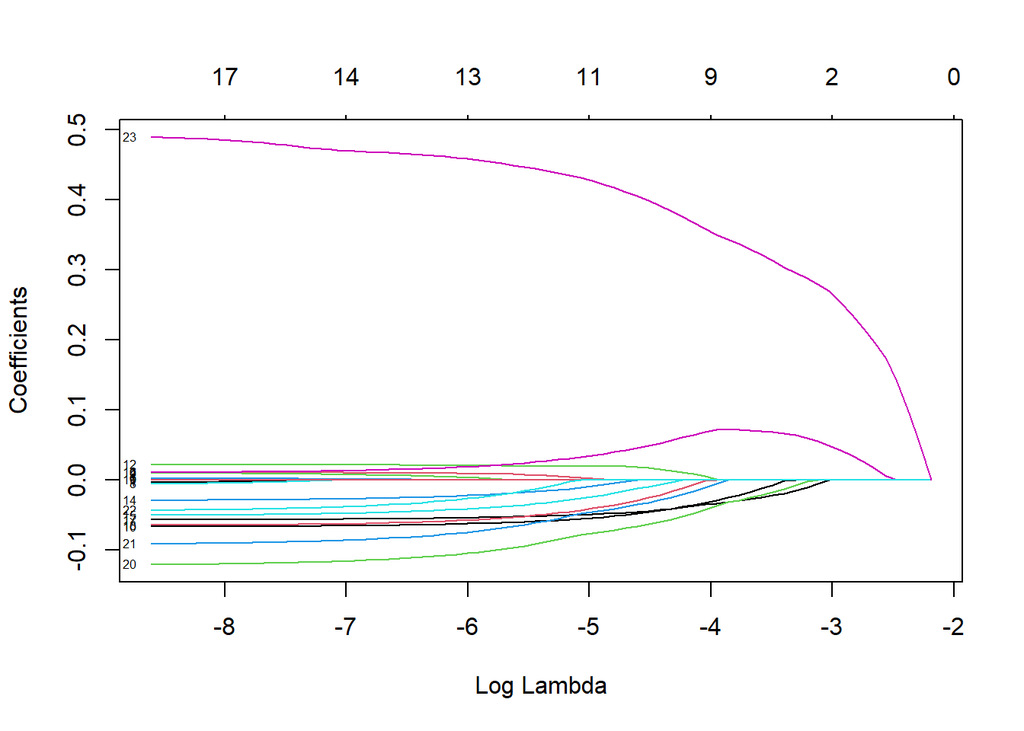

```r
plot(market_cv_lasso$glmnet.fit, "lambda", label = T)
```

```r
coef(market_cv_lasso, market_cv_lasso$lambda.min)
```

```
## 24 x 1 sparse Matrix of class "dgCMatrix"
##                             1
## (Intercept)      1.872441e-01
## Age_Middle      -3.850789e-03
## Age_Old          9.114508e-03
## Age_Young        .
## Gender_Female    9.597812e-03
## Gender_Male      .
## OwnHome_Own      2.117155e-03
## OwnHome_Rent     .
## Married_Married -5.846080e-03
## Married_Single   2.977477e-14
## Location_Close  -6.708856e-02
## Location_Far     .
## Children_0       2.132610e-02
## Children_1       .
## Children_2      -2.933536e-02
## Children_3      -5.085366e-02
## History_High     1.058930e-02
## History_Low     -5.725710e-02
## History_Medium  -6.479497e-02
## History_Unknown  .
## Catalogs_6      -1.212204e-01
## Catalogs_12     -9.164427e-02
## Catalogs_18     -4.365367e-02
## Salary           4.898640e-01
```

```r
lasso.pred_market <- predict(market_cv_lasso, s = market_cv_lasso$lambda.min, newx = as.matrix(market_vars_test))
mse_market <- mean((lasso.pred_market - market_test_tbl$AmountSpent)^2)
mse_market
```

```
## [1] 0.004723122
```

- Use ridge for feature selection.

In this ridge regression model, all variables are statistically significant.

Evaluate: The mean squared error for this model is 0.004730166.

The best model is the model which lambda is equal to lambda.min (in this case, it is 0.01122158, as shown below).

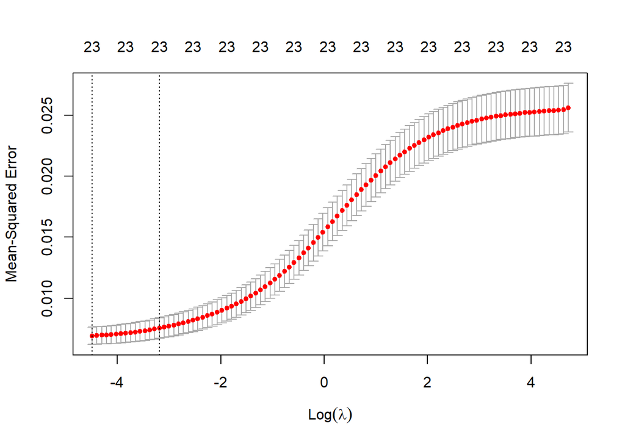

```r
market_cv_ridge <- cv.glmnet(x = as.matrix(market_vars_train), y = market_target_train, alpha = 0)
plot(market_cv_ridge)
```

```r
market_cv_ridge$lambda.min
```

```
## [1] 0.01122158
```

```r
market_cv_ridge$lambda.1se
```

```
## [1] 0.04127725
```

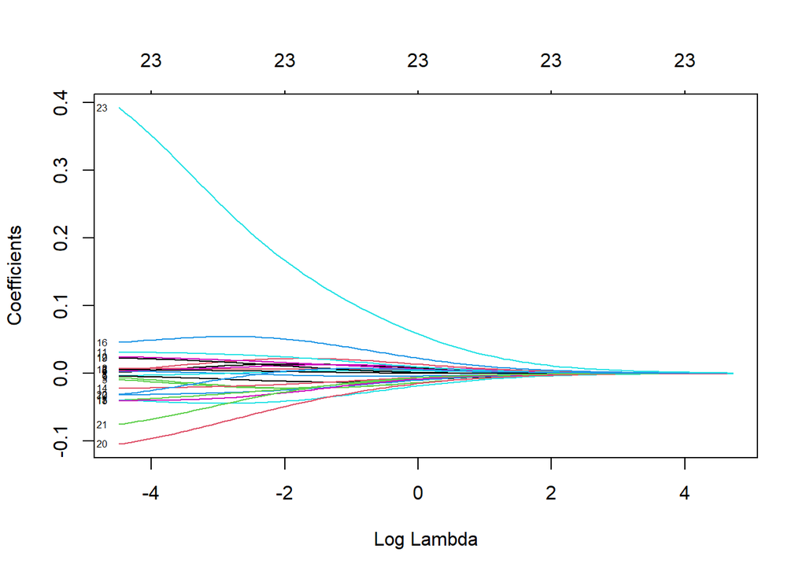

```r
plot(market_cv_ridge$glmnet.fit, "lambda", label = T)
```

```r
coef(market_cv_ridge, market_cv_ridge$lambda.min)
```

```
## 24 x 1 sparse Matrix of class "dgCMatrix"
##                            1
## (Intercept)      0.142126812
## Age_Middle       0.001795953
## Age_Old          0.007333355
## Age_Young       -0.008990737
## Gender_Female    0.003438199
## Gender_Male     -0.003281206
## OwnHome_Own      0.003578249
## OwnHome_Rent    -0.003832949
## Married_Married  0.004913994
## Married_Single  -0.005844724
## Location_Close  -0.031911521
## Location_Far     0.031697781
## Children_0       0.024603792
## Children_1       0.005480494
## Children_2      -0.021966801
## Children_3      -0.039440273
## History_High     0.045756221
## History_Low     -0.038989389
## History_Medium  -0.040111740
## History_Unknown  0.022712920
## Catalogs_6      -0.104212056
## Catalogs_12     -0.075162020
## Catalogs_18     -0.031018701
## Salary           0.392201609
```

```r
ridge.pred_market = predict(market_cv_ridge, s = market_cv_ridge$lambda.min, newx = as.matrix(market_vars_test))
mse_market_ridge <- mean((ridge.pred_market - market_test_tbl$AmountSpent)^2)
mse_market_ridge
```

```
## [1] 0.004730166
```

## Question 4: Apply polynomial and locfit to the analysis

- Apply a polynomial model to the dataset to predict AmountSpent. How does it perform? How did you choose your parameters?

The residual standard error is 0.1111, multiple R-squared is 0.4922, adjusted R-squared is 0.4902, F-statistic is 241.1, and p-value is less than 2.2e-16.

```r
polynomial = function(feature, power){
    return(data.frame(sapply(1:power, function(x){(feature)**x})))
}

for (i in 1:30) {
    dat = polynomial(market_train_tbl$Salary, i)
    dat$AmountSpent = market_train_tbl$AmountSpent
    model = lm(AmountSpent~., data = dat)

    valid_dat = polynomial(market_test_tbl$Salary, i)
    rss = sum((market_test_tbl$AmountSpent - predict.lm(model, newdata = valid_dat))**2)
    print(paste(c("Degree: ", i, " RSS: ", rss), collapse=""))
}
```

```
## [1] "Degree: 1 RSS: 1.96205109160526"
## [1] "Degree: 2 RSS: 1.96256943730731"
## [1] "Degree: 3 RSS: 1.98052665000441"
## [1] "Degree: 4 RSS: 1.96862377514258"
## [1] "Degree: 5 RSS: 1.97379243236359"
## [1] "Degree: 6 RSS: 1.99247790172565"
## [1] "Degree: 7 RSS: 2.00308896821225"
## [1] "Degree: 8 RSS: 2.00499434565338"
## [1] "Degree: 9 RSS: 2.02757047347306"
## [1] "Degree: 10 RSS: 2.02845619485867"
## [1] "Degree: 11 RSS: 2.0369380270163"
## [1] "Degree: 12 RSS: 2.04645277924848"
## [1] "Degree: 13 RSS: 2.04645277924848"
## [1] "Degree: 14 RSS: 2.04624052141689"
## [1] "Degree: 15 RSS: 2.04624052141689"
## [1] "Degree: 16 RSS: 2.04178312725726"
## [1] "Degree: 17 RSS: 2.04178312725726"
## [1] "Degree: 18 RSS: 2.04178312725726"
## [1] "Degree: 19 RSS: 2.0453092771631"
## [1] "Degree: 20 RSS: 2.0453092771631"
## [1] "Degree: 21 RSS: 2.0453092771631"
## [1] "Degree: 22 RSS: 2.04243877438137"
## [1] "Degree: 23 RSS: 2.04243877438137"
## [1] "Degree: 24 RSS: 2.04243877438137"
## [1] "Degree: 25 RSS: 2.04243877438137"
## [1] "Degree: 26 RSS: 2.04243877438137"
## [1] "Degree: 27 RSS: 2.06312315998714"
## [1] "Degree: 28 RSS: 2.06312315998714"
## [1] "Degree: 29 RSS: 2.06312315998714"
## [1] "Degree: 30 RSS: 2.06312315998714"
```

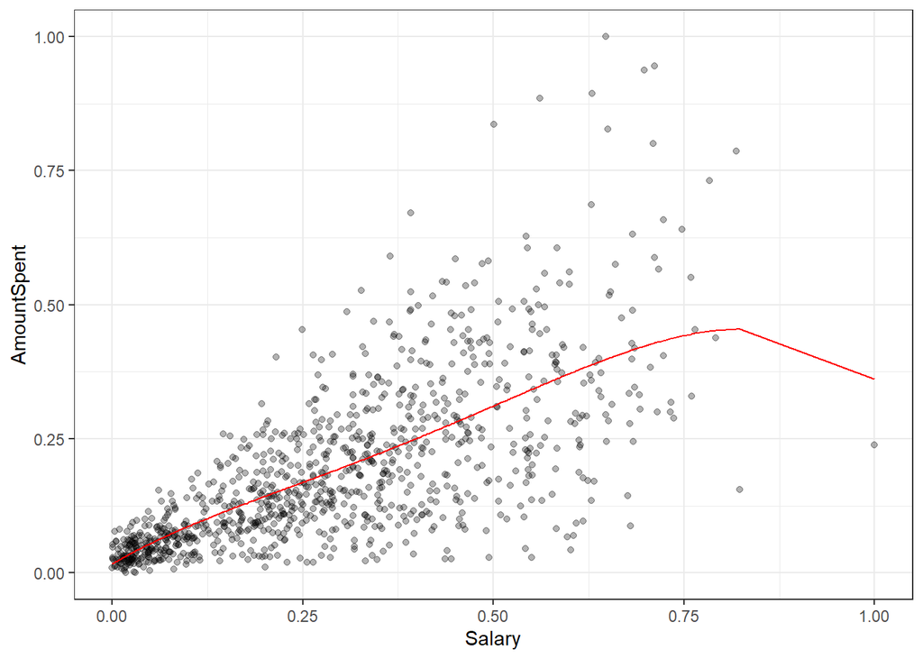

```r
p4_data = polynomial(market$Salary, 4)
p4_data$AmountSpent = market$AmountSpent
p4 = lm(AmountSpent~., data = p4_data)
p4_dat = data.frame(Salary=market$Salary)
p4_dat$AmountSpent = p4$fitted.values

ggplot(market, aes(x=Salary, y=AmountSpent)) + geom_point(alpha=0.3) +
    geom_line(data=p4_dat, color="red") +
    theme_bw()
```

```r
summary(p4)
```

```
##
## Call:
## lm(formula = AmountSpent ~ ., data = p4_data)
##
## Residuals:
##      Min       1Q   Median       3Q      Max
## -0.32991 -0.05297 -0.00752  0.04456  0.60139
##
## Coefficients:
##             Estimate Std. Error t value Pr(>|t|)
## (Intercept)  0.01672    0.01271   1.316 0.188541
## X1           0.82414    0.22587   3.649 0.000277 ***
## X2          -1.52294    1.12068  -1.359 0.174472
## X3           3.16794    2.00699   1.578 0.114780
## X4          -2.12419    1.17537  -1.807 0.071024 .
## ---
## Signif. codes:  0 '***' 0.001 '**' 0.01 '*' 0.05 '.' 0.1 ' ' 1
##
## Residual standard error: 0.1111 on 995 degrees of freedom
## Multiple R-squared:  0.4922, Adjusted R-squared:  0.4902
## F-statistic: 241.1 on 4 and 995 DF,  p-value: < 2.2e-16
```

- Apply a locfit model to the dataset to predict AmountSpent. How does it perform?

It creates a smooth curve between the Salary variable and AmountSpent variable.

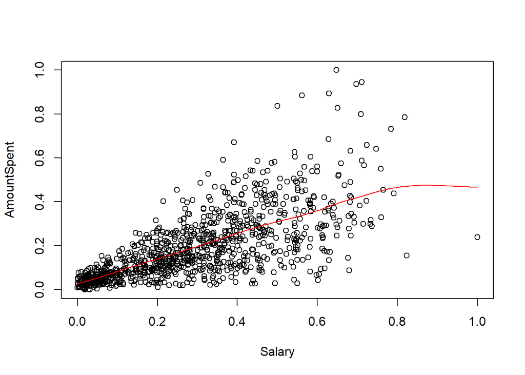

```r
poly_fit <- locfit(AmountSpent~lp(Salary, nn = 0.5), data = market)
plot(market$Salary, market$AmountSpent, xlab = "Salary", ylab = "AmountSpent")
lines(poly_fit, col="red")
```

```r
summary(poly_fit)
```

```
## Estimation type: Local Regression
##
## Call:
## locfit(formula = AmountSpent ~ lp(Salary, nn = 0.5), data = market)
##
## Number of data points:  1000
## Independent variables:  Salary
## Evaluation structure: Rectangular Tree
## Number of evaluation points:  11
## Degree of fit:  2
## Fitted Degrees of Freedom:  6.946
```